# 11. Fracciones y porcentajes

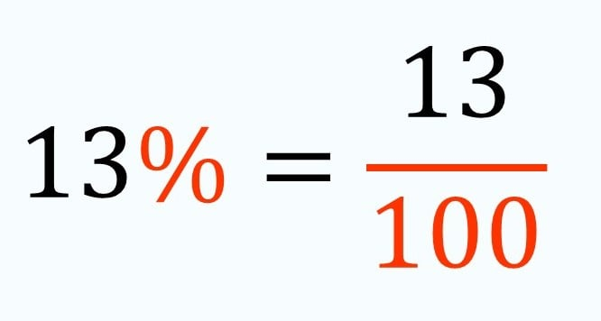

Fuente: smartick.es

**Aclaraciones**

- Las actividades con 🔁 son de **autocorrección**.
- Primero hacelas vos, después compará con la solución al final de la guía:
  - Si está bien: marcá **✓**.
  - Si está mal: copiá la solución intentando entenderla y marcá **✓✓**.
  - Si todavía no lo entendés: preguntá en clase.
- Corregirte a vos mismo te va a ayudar a aprender más rápido y a llegar mejor preparado a las pruebas.

## ¿Qué es un porcentaje?

La palabra **porcentaje** viene de *“por cada cien”*. El símbolo es **%**. Un porcentaje muestra cuántas partes de cada **100** tomamos.

- Ejemplo: **25%** significa **25 de cada 100**.
- También se puede escribir como fracción: $\tfrac{25}{100}$

Entonces: $25\% = \frac{25}{100}$

Puedes ver esta explicación [aquí](https://www.youtube.com/watch?v=y79lq0m7dSA).

## 🔁 Actividad 1

Pon estos porcentajes como fracción y simplifícalas. Por ejemplo 50% = $\tfrac{50}{100}$ y simplificando queda $\tfrac{1}{2}$:

**1.** 25%

**2.** 10%

**3.** 1%

**4.** 5%

**5.** 12,5%

Convierte estas fracciones en porcentajes, por ejemplo $\tfrac{32}{100}$ es 32%:

**1.** $\tfrac{23}{100}$

**2.** $\tfrac{97}{100}$

**Para los siguientes ten en cuenta ésto:** Si el denominador no es 100, por ejemplo $\tfrac{3}{4}$ hazlo así: $\tfrac{3 \cdot 25}{4 \cdot 25}$ = $\tfrac{75}{100}$. Es decir multiplicas por un mismo número de modo que el denominador llegue a 100.

**3.** $\tfrac{2}{5}$

**4.** $\tfrac{8}{20}$

**5.** $\tfrac{12}{50}$

## ¿Cómo calcular un porcentaje de un número?

Un modo es multiplicar el número por el porcentaje en forma de fracción como se muestra [aquí](https://www.youtube.com/watch?v=TGyHGwhS90A)

- Ejemplo: ¿Cuánto es el **20% de 50**?

  20% de 50 = $\frac{20}{100} \cdot \frac{50}{1}$ = $\frac{20}{2} \cdot \frac{1}{1}$ = **10**

## 🔁 Actividad 3

Resuelve lo siguiente:

**1.** ¿Cuánto es el **50% de 60**?

**2.** ¿Cuánto es el **25% de 120**?

**3.** Si un celular cuesta $40.000 y tiene **10% de descuento**, ¿cuánto pagas?

**4.** Si Leon junta cada semana el 5% de una bicicleta que sale 350.000 pesos. ¿cuántos pesos junta cada semana?

**5.** En un examen de 50 preguntas, un alumno respondió bien el 46%. ¿Cuántas prguntas acertó?

**Soluciones para autocorregirte**

### Actividad 1

- **1.** 25% = $\tfrac{25}{100}$ y simplificando queda $\tfrac{1}{4}$
- **2.** 10% = $\tfrac{10}{100}$ y simplificando queda $\tfrac{1}{10}$
- **3.** 1% = $\tfrac{1}{100}$
- **4.** 5% = $\tfrac{5}{100}$ y simplificando queda $\tfrac{1}{20}$
- **5.** 12,5% = $\tfrac{12,5}{100}$

### Actividad 3

**1.** 50% de 60 = $\frac{50}{100} \cdot \frac{60}{1}$ = 30

**2.** 25% de 120 = $\frac{25}{100} \cdot \frac{120}{1}$= 30

**3.** Compra del celular

- Descuento: 10 % de 40.000 = $\frac{10}{100} \cdot \frac{40.000}{1}$= $\frac{10}{1} \cdot \frac{400}{1}$ = 4.000
- Paga: 40.000 - 4.000 = 36.000
- **Respuesta:** Pagas 36.000 pesos

**4.** Bici de Leon:

- Ahorro semanal: 5 % de 350.000 = $\frac{5}{100} \cdot \frac{350.000}{1}$ = $\frac{5}{1} \cdot \frac{3.500}{1}$ = 17.500
- **Respuesta:** Cada semana ahorra 17.500 pesos

**5.** Examen:

- Porcentaje de aciertos: 46 % de 50 = $\frac{46}{100} \cdot \frac{50}{1}$ = $\frac{46}{2} \cdot \frac{1}{1}$ = 23
- **Respuesta:** Respondió bien 23 preguntas